# Yamanaka_RNASeq_Analysis

2025-12-12

Documentation of used code.

## Load gene counts table

I am setting the directory and giving the name for the gene count table to be loaded into the R environment.

```r
genecount_file <- "gene_counts_YFproject.csv"

file_path <- here("data", "processed_data", "counts_data", genecount_file)

M <- read.csv(file_path,
              header = TRUE,
              quote = "",
              check.names = FALSE,
              stringsAsFactors = FALSE,
              row.names = 1)   # <- FIRST COLUMN as row names
```

### Adjust column and row names

```r
# --- Clean column names (sample names) ---
colnames(M) <- colnames(M) %>%
  str_remove_all('"') %>%        # remove any quotes
  str_remove("^K_") %>%          # remove prefix "K_"
  str_remove("_sorted\\.bam$")   # remove suffix "_sorted.bam"

# --- Clean row names (Entrez IDs) ---
rownames(M) <- rownames(M) %>%
  str_remove_all('"')             # remove any quotes

# display the first 6 rows:
dt <- DT::datatable(M |> head())
dt
```

|  | Y340 | Y341 | Y342 | Y343 | Y344 | Y345 | Y346 | Y347 | Y348 | Y349 | Y350 | Y351 | Y352 | Y353 | Y354 | Y355 | Y356 |
| --- | --- | --- | --- | --- | --- | --- | --- | --- | --- | --- | --- | --- | --- | --- | --- | --- | --- |
| 115487594 | 0 | 0 | 0 | 0 | 0 | 0 | 0 | 0 | 0 | 0 | 0 | 0 | 0 | 0 | 0 | 0 | 0 |
| 497097 | 2 | 7 | 3 | 1 | 1 | 9 | 6 | 1 | 3 | 4 | 1 | 4 | 1 | 1 | 0 | 1 | 2 |
| 108167595 | 0 | 0 | 0 | 0 | 0 | 0 | 0 | 0 | 0 | 0 | 0 | 0 | 0 | 0 | 0 | 0 | 0 |
| 115487633 | 0 | 0 | 0 | 0 | 0 | 0 | 0 | 0 | 0 | 0 | 0 | 0 | 0 | 0 | 0 | 0 | 0 |
| 19888 | 29 | 20 | 22 | 10 | 23 | 16 | 17 | 14 | 17 | 22 | 18 | 18 | 12 | 14 | 15 | 9 | 19 |
| 619785 | 0 | 0 | 0 | 0 | 0 | 0 | 0 | 0 | 0 | 0 | 0 | 0 | 0 | 0 | 0 | 0 | 0 |

I will perform the DESeq2 analysis still using the EntrezIDs because if I transform them into gene names first, I will lose information, since not all EntrezIDs have different gene names (there are duplicates, or NAs).

## Optimize data before analysis

```r
#discard genes with a total count < 10
min_count <- 10
M <- M[rowSums(M) >= min_count,] #this steps reduces the amount of detected genes from 45569 to 23150
```

## Set up the Input for DESeq2

In order to run the DESeq2 analysis, we need a meta table containing all information of different groups and treatments.

```r
# Sample names must match the count matrix column names
sample_names <- c("Y340", "Y341", "Y342", "Y343", "Y344", "Y345", "Y346", "Y347", "Y348", "Y349",
                  "Y350", "Y351", "Y352", "Y353", "Y354", "Y355", "Y356")

# Create metadata
colData <- data.frame(
  row.names = sample_names,
  time = c("3d", "3d", "3d", "3d", "3d", "3d", "3d", "3d", "2wks", "2wks",
           "2wks", "2wks", "2wks", "2wks", "2wks", "2wks", "2wks"),
  genotype = c("Ctrl", "CrePos", "CrePos", "Ctrl", "Ctrl", "CrePos", "CrePos", "Ctrl", "CrePos", "CrePos",
               "Ctrl", "Ctrl", "Ctrl", "CrePos", "CrePos", "CrePos", "Ctrl"),
  age_dis = c(129, 129, 107, 107, 83, 83, 55, 55, 121, 121,
              121, 121, 97, 97, 97, 69, 69), #age at dissection
  age_ind = c(126, 126, 104, 104, 80, 80, 52, 52, 104, 104,
              104, 104, 80, 80, 80, 52, 52) # age at doxycycline induction
)

# We will only use either age at dissection or age at doxycycline induction.

# Make sure group/treatment are factors
colData$time <- factor(colData$time)
colData$genotype <- factor(colData$genotype)

#Set reference levels
colData$time <- relevel(colData$time, ref = "3d")
colData$genotype <- relevel(colData$genotype, ref = "Ctrl")

is.numeric(colData$age_dis)  # should be TRUE
```

```
## [1] TRUE
```

```r
is.numeric(colData$age_ind)  # should be TRUE
```

```
## [1] TRUE
```

## Run DESeq2 Analysis

After setting up the input, we can run the actual analysis. Let’s first check if the induction effect of Yamanaka factors in Pax8-Cre positive animals is strong enough to manifest irrespective of time and age.

### Analysis 1 - Induction effect solo

Running the first analysis

```r
dds_genotype <- DESeqDataSetFromMatrix(
  countData = M,
  colData = colData,
  design = ~ ~ 1 + genotype #in theory you could leave out the "1 + " because this is the default
  )
dds_genotype <- DESeq(dds_genotype)
```

```
## -- replacing outliers and refitting for 47 genes
## -- DESeq argument 'minReplicatesForReplace' = 7
## -- original counts are preserved in counts(dds)
```

```r
#available test results listed
resultsNames(dds_genotype)
```

```
## [1] "Intercept"               "genotype_CrePos_vs_Ctrl"
```

```r
#see genotype effect
res_genotype <-
  results(dds_genotype,
          name="genotype_CrePos_vs_Ctrl"
  )


#put results in a nice table
dt <- DT::datatable(
  res_genotype |> as.data.frame() |>
    dplyr::filter(!is.na(padj), padj <= 0.05) |>
    dplyr::arrange(padj),

  options=list(scrollY="500px")
)

# convert numeric columns to scientific notation
dt <- dt |>
  DT::formatSignif(
    sapply(dt$x$data, is.numeric),
    digits=2
  )
dt
```

|  | baseMean | log2FoldChange | lfcSE | stat | pvalue | padj |
| --- | --- | --- | --- | --- | --- | --- |
| 83453 | 62.27317688104105 | -2.685447509128117 | 0.1664911911190282 | -16.12966722790896 | 1.578687639655522e-58 | 2.875263798104602e-54 |
| 75400 | 790.676134194159 | -1.260855634174409 | 0.08276372014052907 | -15.23440019411323 | 2.090366752029072e-52 | 1.903592482735275e-48 |
| 15483 | 1994.996263471513 | -1.381562319754104 | 0.1053858360607092 | -13.10956359408899 | 2.902638330099076e-39 | 1.762191730203149e-35 |
| 408066 | 470.7779888851828 | -0.833776857685156 | 0.07007484536999943 | -11.89837599045369 | 1.206726253909011e-32 | 5.494526315611206e-29 |
| 114664 | 4913.589879838117 | -1.066178149716104 | 0.09946893075043235 | -10.71870524466726 | 8.3159265025906e-27 | 2.524299489861377e-23 |
| 104080 | 99.66185508601131 | -1.564181324865541 | 0.1457433447262816 | -10.7324374077129 | 7.16801140469995e-27 | 2.524299489861377e-23 |
| 20342 | 1766.556184522221 | 1.736711819852681 | 0.1664308447927063 | 10.43503577726712 | 1.715491205510105e-25 | 4.463463046565076e-22 |
| 18510 | 2958.312629075967 | 1.002081511509639 | 0.1008037945726124 | 9.940910615103933 | 2.762897810384258e-23 | 6.290082227566062e-20 |
| 74088 | 1928.946191518169 | -0.638849332911436 | 0.06694561170805034 | -9.542811195712968 | 1.390119738843001e-21 | 2.813138978171954e-18 |
| 11814 | 356.229128980221 | 1.506842820579054 | 0.1588030306411669 | 9.488753548941599 | 2.338132384687226e-21 | 4.258440512230844e-18 |

[output cut: 1463 more lines]

Now run quality control (QC) on this analysis, to check for batch effects, outliers, sample swaps with a first PCA.

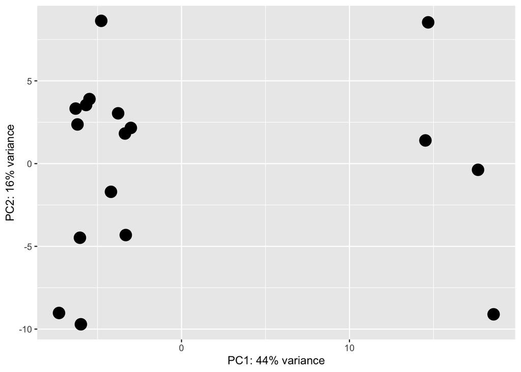

```r
#### Preparation for PCA ####
# The "blind" parameter tells the function NOT to use the input object's model formula for identifying "valid" (expected) variation.
# We do this here because we have not yet found an optimal formula.
# For QC and testing for batch effects we will use the "blind" parameter.

vsd_blind <- vst(dds_genotype, blind=TRUE)

saveRDS(vsd_blind,file="results/qc/vsd_blind_genotype.rds")

plotPCA2(vsd_blind,
         intgroup = "genotype",
         ntop=500,
         PCs=c(x=1,y=2))
```

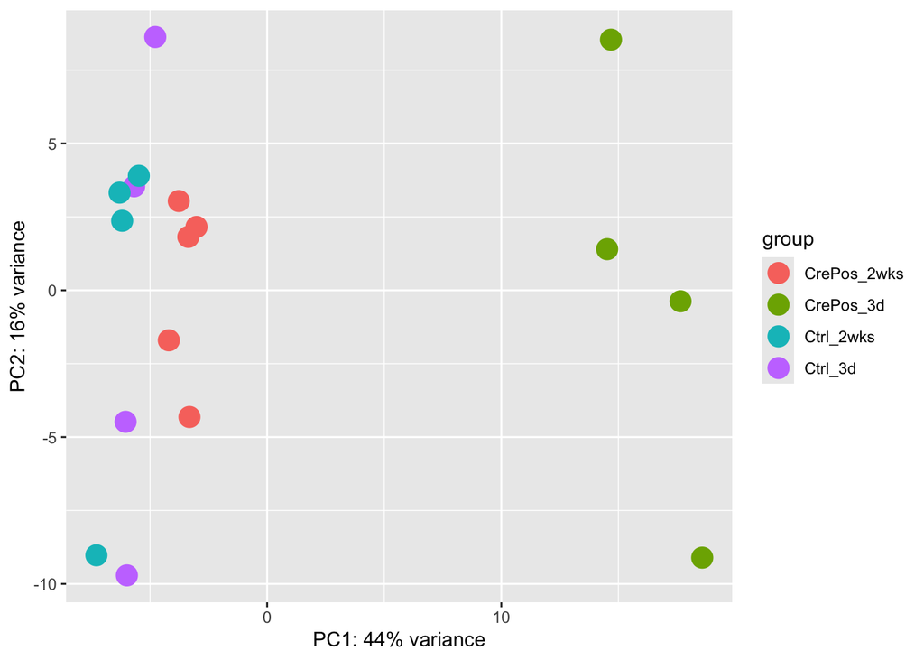

```r
# plot PCA, coloring different genotypes and times
colData(vsd_blind)$genotype_time <- factor(
  paste(colData(vsd_blind)$genotype, colData(vsd_blind)$time, sep="_")
)

plotPCA2(vsd_blind,
         intgroup = "genotype_time",
         ntop = 500,
         PCs = c(x=1, y=2),
         colour = group)  # <- this maps colors)
```

Now creating a heatmap of the 500 most highly expressed genes.

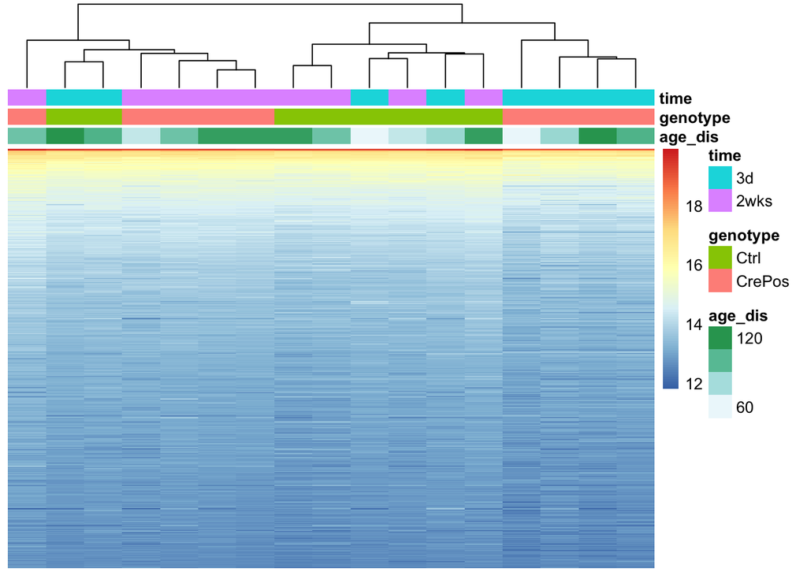

```r
# Select top 500 most expressed genes (after DESeq2 normalization)
selected <-
  order(rowMeans(counts(dds_genotype,
                        normalized=TRUE)
  ),
  decreasing=TRUE)[1:500]

# Create a metadata dataframe for annotation
df <- as.data.frame(colData(dds_genotype))[, c("age_dis", "genotype", "time")]

# Optional: make factors for annotation
df$genotype <- factor(df$genotype)
df$time <- factor(df$time)

pheatmap(assay(vsd_blind)[selected,],
         cluster_rows=FALSE,
         show_rownames=FALSE,
         show_colnames=FALSE,
         cluster_cols=TRUE,
         annotation_col=df)
```

In order to check if the normalization “worked”, I will plot a boxplot of the per-sample count distributions. All medians should be aligned.

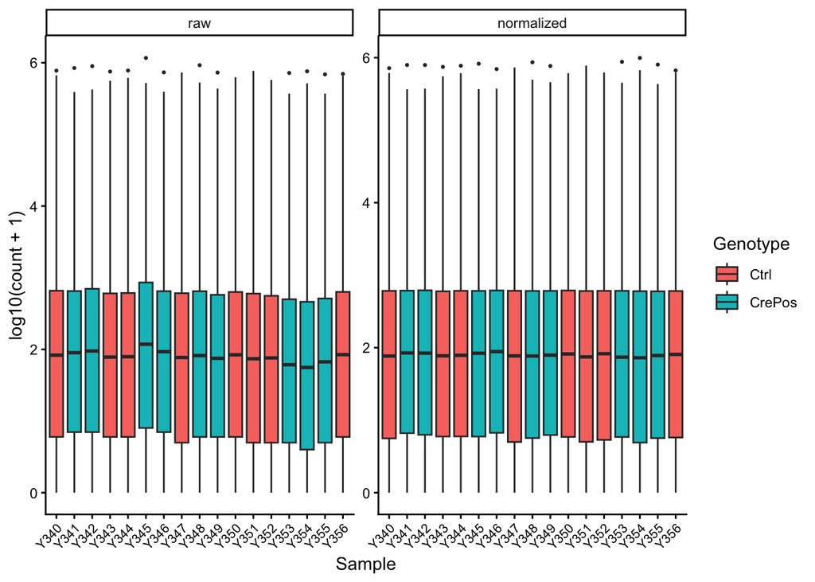

```r
# melt counts
df <- rbind(
  reshape2::melt(log10(counts(dds_genotype, normalized=FALSE) + 1)) %>% mutate(mode="raw"),
  reshape2::melt(log10(counts(dds_genotype, normalized=TRUE) + 1)) %>% mutate(mode="normalized")
) %>%
  dplyr::rename(gene=Var1, sample=Var2, count=value) %>% # rename to make variable names more meaningful
  # merge metadata so you can color/fill by it
  left_join(
    as.data.frame(colData(dds_genotype)) %>% mutate(sample = rownames(.)),
    by = "sample"
  ) %>%
  mutate(mode = factor(mode, levels=c("raw","normalized")))

# boxplot colored by genotype
ggplot(df, aes(x = sample, y = count, fill = genotype)) +
  geom_boxplot(outlier.size = 0.5) +
  facet_wrap(~mode, scales = "free_y", ncol = 2) +
  theme_classic() +
  theme(axis.text.x = element_text(angle = 45, hjust = 1, size = 8)) +
  labs(x = "Sample", y = "log10(count + 1)", fill = "Genotype")
```

```r
cnt <- counts(dds_genotype,normalized=TRUE)
medians_log10 <- log10(colMedians(cnt |> as.matrix())+1)

tapply(medians_log10, # what to group
           names(medians_log10),
       mean  # function to apply to grouped values
) |>
  sort(decreasing=TRUE) # sort the result
```

```
##     Y346     Y341     Y342     Y345     Y352     Y350     Y356     Y349
## 1.946013 1.927295 1.924419 1.922963 1.917002 1.913309 1.907194 1.897057
##     Y344     Y355     Y343     Y347     Y348     Y340     Y351     Y353
## 1.895028 1.892109 1.888228 1.887481 1.885293 1.884900 1.872510 1.869260
##     Y354
## 1.862013
```

```r
colMeans <- apply(cnt, 2, mean)
colMeans
```

```
##     Y340     Y341     Y342     Y343     Y344     Y345     Y346     Y347
## 880.4479 813.9098 837.6492 897.5529 891.6216 833.0856 804.0694 877.7621
##     Y348     Y349     Y350     Y351     Y352     Y353     Y354     Y355
## 888.8597 870.2539 844.6091 918.9035 854.3727 895.5219 968.0619 868.7433
##     Y356
## 862.5904
```

There is not a sample that differs broadly from the others, nor is there a broad batch effect visible. Medians and means are very much aligned.

### Analysis 2 - Calculate multivariate DESeq2 model

Performing DESeq-Analysis for more factors lets the system structure the data better, accounting for different variability, and therefore may expose more of significant, although small, effects of the genotype factor.

The model I want to apply looks like this:

- effect of interest: genotype
- additional effect: time
- covariate to control for: age_dis (numeric, Age of dissection)

Biological question is: “What genes differ by genotype, accounting for time after induction and age at dissection?”

```r
dds_multi <-
  DESeqDataSetFromMatrix(countData = M,
                         colData = colData,
                         design= ~ age_dis + time + genotype #age_dis is treated as a continuous covariate
  ) |>
  DESeq()

qsave(dds_multi, "results/differential_expression/dds_multi.qs")

resultsNames(dds_multi)
```

```
## [1] "Intercept"               "age_dis"
## [3] "time_2wks_vs_3d"         "genotype_CrePos_vs_Ctrl"
```

```r
#Have a Look at the Genotype Effect in this Model
res_multi <-
  results(dds_multi, name="genotype_CrePos_vs_Ctrl")
```

I will now transform Entrez IDs that were in the BAM files to gene names using org.Mm.eg.db and add to the results table.

```r
# Convert Entrez IDs of my res_results to gene symbols
entrez_ids <- rownames(res_multi)
gene_symbols <- mapIds(org.Mm.eg.db,
                       keys = entrez_ids,
                       column = "SYMBOL",
                       keytype = "ENTREZID",
                       multiVals = "first")  # take first if multiple matches
#Add gene symbols to the results table
res_multi_df <- as.data.frame(res_multi) |>
  mutate(
    entrez_id   = rownames(res_multi),
    gene_symbol = gene_symbols[entrez_id]
  )

# Convert Entrez IDs of my res_results to gene names
gene_names <- mapIds(
  org.Mm.eg.db,
  keys      = entrez_ids,
  column    = "GENENAME",
  keytype   = "ENTREZID",
  multiVals = "first"
)
#Add gene names to the results table
res_multi_df <- res_multi_df |>
  mutate(gene_name = gene_names[entrez_id])

#Check how many Entrez IDs do not correlate to a gene symbol
table(is.na(res_multi_df$gene_symbol))
```

```
##
## FALSE  TRUE
## 23082    68
```

```r
# actually 68 genes are not connected to a gene symbol

qsave(res_multi_df, "results/differential_expression/res_multi_df.qs")
```

Now let’s look at the gene table.

```r
#make a table
dt <- DT::datatable(
  res_multi_df |> as.data.frame() |>
    dplyr::filter(!is.na(padj), padj <= 0.05) |>
    dplyr::arrange(padj),

  options=list(scrollY="500px",
               lengthMenu = list(c(10, -1),
                                 c('10','All'))
  )
)

# convert numeric columns to scientific notation
dt <- dt |>
  DT::formatSignif(sapply(dt$x$data, is.numeric),
                   digits=2
  )
dt
```

|  | baseMean | log2FoldChange | lfcSE | stat | pvalue | padj | entrez_id | gene_symbol | gene_name |
| --- | --- | --- | --- | --- | --- | --- | --- | --- | --- |
| 83453 | 62.27317688104105 | -2.695036288647759 | 0.1624941357646137 | -16.58543722803477 | 8.881695451352303e-62 | 1.577744379978223e-57 | 83453 | Chrdl1 | chordin-like 1 |
| 75400 | 790.676134194159 | -1.258920073682088 | 0.08324324008746942 | -15.12339106886341 | 1.135418869789959e-51 | 1.008479040147442e-47 | 75400 | Defb29 | defensin beta 29 |
| 15483 | 1994.996263471513 | -1.378856289201878 | 0.102859168685924 | -13.40528323160141 | 5.630790788825338e-41 | 3.334178919089777e-37 | 15483 | Hsd11b1 | hydroxysteroid 11-beta dehydrogenase 1 |
| 18510 | 2958.312629075967 | 1.011145252999583 | 0.07921326721464651 | 12.76484720999644 | 2.576557256559451e-37 | 1.144249077638052e-33 | 18510 | Pax8 | paired box 8 |
| 105892 | 617.6246096075388 | 1.273746341585478 | 0.1053614639255826 | 12.08929995966203 | 1.203074350778705e-33 | 4.274282553446583e-30 | 105892 | 9030619P08Rik | lymphocyte antigen 6 complex pseudogene |
| 408066 | 470.7779888851828 | -0.836031381525479 | 0.07035166065047893 | -11.88360550121268 | 1.440185676835294e-32 | 4.263909727217026e-29 | 408066 | Cspg4b | chondroitin sulfate proteoglycan 4B |
| 209195 | 218.9406095113961 | 4.473362278320174 | 0.3777883435248751 | 11.8409219209423 | 2.398023333337093e-32 | 6.085498070485732e-29 | 209195 | Clic6 | chloride intracellular channel 6 |
| 104080 | 99.66185508601131 | -1.567935044748933 | 0.1379890527026983 | -11.3627495372919 | 6.409503564730121e-30 | 1.423230266548323e-26 | 104080 | Nxph4 | neurexophilin 4 |
| 74488 | 92.47492438636539 | 2.144851510385542 | 0.1912632531026651 | 11.21413274945314 | 3.475767080823806e-29 | 6.860391824861565e-26 | 74488 | Lrrc15 | leucine rich repeat containing 15 |
| 20342 | 1766.556184522221 | 1.741738208469056 | 0.1577570097499958 | 11.04063908937715 | 2.432964941317283e-28 | 4.321918921756021e-25 | 20342 | Selenbp2 | selenium binding protein 2 |

[output cut: 1867 more lines]

Looking now at the PCA with the new analysis and not blind VST.

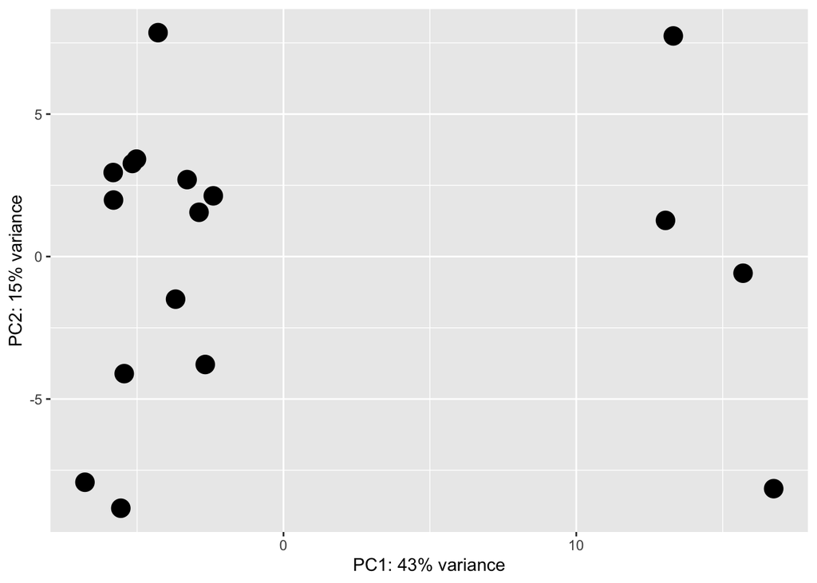

```r
vsd_unblind <- vst(dds_multi, blind=FALSE)

saveRDS(vsd_blind,file="results/qc/vsd_unblind_genotype.rds")

plotPCA2(vsd_unblind,
         intgroup = "genotype",
         ntop=500,
         PCs=c(x=1,y=2))
```

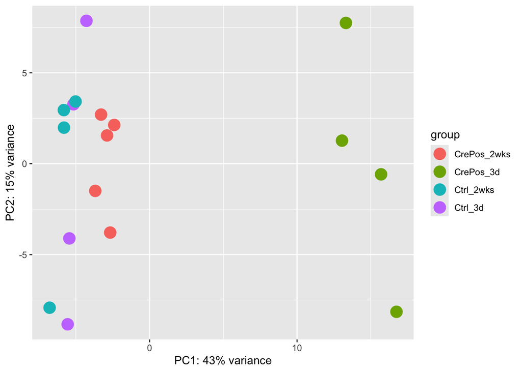

```r
# plot PCA, coloring different genotypes and times
colData(vsd_unblind)$genotype_time <- factor(
  paste(colData(vsd_unblind)$genotype, colData(vsd_blind)$time, sep="_")
)

plotPCA2(vsd_unblind,
         intgroup = "genotype_time",
         ntop = 500,
         PCs = c(x=1, y=2),
         colour = group)  # <- this maps colors)
```

It looks nearly identical to the “blind” version of the VST.

## Overrepresentation Analysis

Now coming to the interpretable analyses, I will start with ORA.

```r
#if starting from here, load dds_multi
res_multi_df <- qread("results/differential_expression/res_multi_df.qs")

#set "Universe" - defined as all genes that are actually expressed
uni_genes <- res_multi_df |>
  dplyr::filter(!is.na(padj)) |>
  dplyr::pull(gene_symbol) |>
  unique()

#upregulated genes
de_genes_up <- res_multi_df |>
  dplyr::filter(!is.na(padj), padj <= 0.05, log2FoldChange > 0) |>
  dplyr::pull(gene_symbol) |>
  unique()

#downregulated genes
de_genes_dn <- res_multi_df |>
  dplyr::filter(!is.na(padj), padj <= 0.05, log2FoldChange < 0) |>
  dplyr::pull(gene_symbol) |>
  unique()

ego_result_up <- enrichGO(gene = de_genes_up,
                          universe = uni_genes,
                          OrgDb = org.Mm.eg.db,
                          keyType = "SYMBOL",
                          ont = "BP",
                          pAdjustMethod = "BH",
                          pvalueCutoff = 0.05,
                          qvalueCutoff = 0.2,
                          readable = TRUE)


DT::datatable(head(ego_result_up)) # shows all genes that are now enriched for the pathways and how many there are
```

|  | ID | Description | GeneRatio | BgRatio | RichFactor | FoldEnrichment | zScore | pvalue | p.adjust | qvalue | geneID | Count |
| --- | --- | --- | --- | --- | --- | --- | --- | --- | --- | --- | --- | --- |
| GO:0007051 | GO:0007051 | spindle organization | 36/904 | 201/14763 | 0.1791044776119403 | 2.924910844010038 | 7.017606347454825 | 5.043311830027192e-09 | 1.217882960458432e-05 | 1.179062750441097e-05 | Ntmt1/Spc25/Knstrn/Mybl2/Aurka/Chmp4c/Psrc1/Cdc20/Stmn1/Auni…… | 36 |
| GO:0044786 | GO:0044786 | cell cycle DNA replication | 15/904 | 41/14763 | 0.3658536585365854 | 5.974665443557091 | 8.146353820774323 | 8.022248054255908e-09 | 1.217882960458432e-05 | 1.179062750441097e-05 | Mcm3/Mcm6/Rad51/Gins1/Dbf4/Mcm7/Mcm2/Lig1/Fgfr1/Mcm5/Fbxo5/Cdk1/Tk1/Gmnn/Pola1 | 15 |
| GO:1902969 | GO:1902969 | mitotic DNA replication | 10/904 | 17/14763 | 0.5882352941176471 | 9.606324830817282 | 9.067675043438221 | 9.255672155015273e-09 | 1.217882960458432e-05 | 1.179062750441097e-05 | Mcm3/Mcm6/Rad51/Gins1/Mcm2/Lig1/Fgfr1/Cdk1/Tk1/Pola1 | 10 |
| GO:0033260 | GO:0033260 | nuclear DNA replication | 14/904 | 36/14763 | 0.3888888888888889 | 6.350848082595871 | 8.209327777809367 | 1.007972655045257e-08 | 1.217882960458432e-05 | 1.179062750441097e-05 | Mcm3/Mcm6/Rad51/Gins1/Dbf4/Mcm7/Mcm2/Lig1/Fgfr1/Mcm5/Cdk1/Tk1/Gmnn/Pola1 | 14 |
| GO:0007059 | GO:0007059 | chromosome segregation | 54/904 | 395/14763 | 0.1367088607594937 | 2.232558530301333 | 6.341599460081824 | 2.140949352750633e-08 | 2.069441644368761e-05 | 2.003477867995066e-05 | Dis3l2/Kif14/Cenpf/Ntmt1/Nek6/Spc25/Knstrn/Nusap1/Ncaph/Mybl…… | 54 |
| GO:0006261 | GO:0006261 | DNA-templated DNA replication | 28/904 | 149/14763 | 0.1879194630872483 | 3.068866187563105 | 6.482340697319005 | 8.90441505376993e-08 | 7.172506325811678e-05 | 6.943881563860937e-05 | Mcm3/Bard1/Zranb3/Mcm6/Parp1/Rad51/Gins1/Dbf4/Pole/Mcm7/Rfc3/Mcm2/Lig1/Pold1/Rrm1/Fgfr1/Mcm5/Fbxo5/Cdk1/Prim1/Pold2/Eme1/Brca1/Tk1/Gmnn/Wrnip1/Tonsl/Pola1 | 28 |

```r
ego_result_dn <- enrichGO(
  gene = de_genes_dn,
  universe = uni_genes,
  OrgDb = org.Mm.eg.db,
  keyType = "SYMBOL",
  ont = "BP",
  pAdjustMethod = "BH",
  pvalueCutoff = 0.05,
  qvalueCutoff = 0.2,
  readable = TRUE
)

DT::datatable(head(ego_result_dn))
```

|  | ID | Description | GeneRatio | BgRatio | RichFactor | FoldEnrichment | zScore | pvalue | p.adjust | qvalue | geneID | Count |
| --- | --- | --- | --- | --- | --- | --- | --- | --- | --- | --- | --- | --- |
| GO:0015711 | GO:0015711 | organic anion transport | 62/811 | 399/14763 | 0.1553884711779449 | 2.828606658446362 | 8.927581842841464 | 7.61376978898683e-14 | 3.639381959135705e-10 | 3.464665978714744e-10 | Lypla1/Pla2r1/Lrp2/Slc1a2/Slc27a2/Slc10a5/Slc33a1/Slc16a4/Sl…… | 62 |
| GO:0046942 | GO:0046942 | carboxylic acid transport | 48/811 | 313/14763 | 0.1533546325878594 | 2.791583774222649 | 7.723962552648263 | 8.706635131980688e-11 | 1.738954945847847e-07 | 1.655472854195165e-07 | Lypla1/Pla2r1/Lrp2/Slc1a2/Slc27a2/Slc10a5/Slc16a4/Slc7a13/Sl…… | 48 |
| GO:0015849 | GO:0015849 | organic acid transport | 48/811 | 315/14763 | 0.1523809523809524 | 2.773859432799014 | 7.672473656814525 | 1.091394317477728e-10 | 1.738954945847847e-07 | 1.655472854195165e-07 | Lypla1/Pla2r1/Lrp2/Slc1a2/Slc27a2/Slc10a5/Slc16a4/Slc7a13/Sl…… | 48 |
| GO:0043603 | GO:0043603 | amide metabolic process | 57/811 | 450/14763 | 0.1266666666666667 | 2.30577065351418 | 6.782231645209639 | 2.838032871982354e-09 | 3.391449282018913e-06 | 3.22863581725782e-06 | Pam/Nit1/Hsd11b1/Cers6/Slc1a2/Acss2/Fitm2/B4galt5/Cers2/Ugt8…… | 57 |
| GO:0008202 | GO:0008202 | steroid metabolic process | 42/811 | 293/14763 | 0.1433447098976109 | 2.609368621724328 | 6.708414175068453 | 1.044524941325166e-08 | 9.985658439068588e-06 | 9.506276465997248e-06 | Lbr/Hsd11b1/Lrp2/Osbpl6/Slc27a2/Cyp7b1/Fmo5/Hsd3b2/Ttc39b/H6…… | 42 |
| GO:0006790 | GO:0006790 | sulfur compound metabolic process | 36/811 | 266/14763 | 0.1353383458646616 | 2.463625154130703 | 5.807596133188452 | 4.996697029641281e-07 | 0.0003909079977308988 | 0.0003721416591479135 | Slc1a2/Acss2/Fitm2/Papss1/Crot/Sult1d1/Tpk1/Snca/Eif2ak3/Mat…… | 36 |

#### Visualization of ORA

There are many different plot types that we can use for visualization.

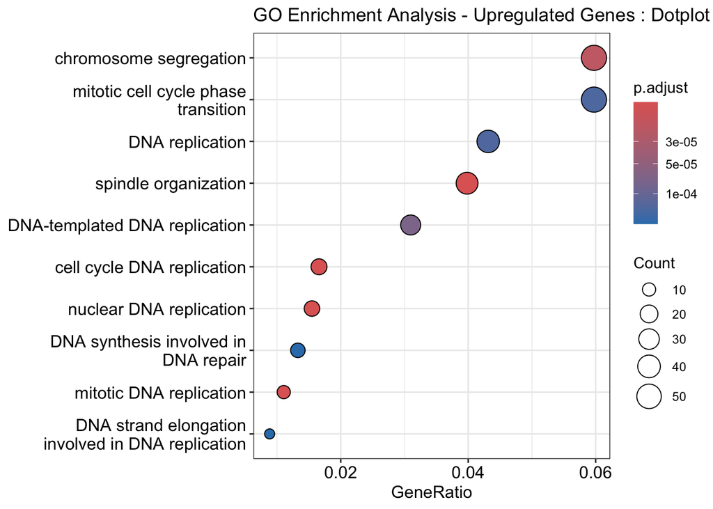

```r
dotplot(ego_result_up, showCategory=10) +
  ggtitle("GO Enrichment Analysis - Upregulated Genes : Dotplot")
```

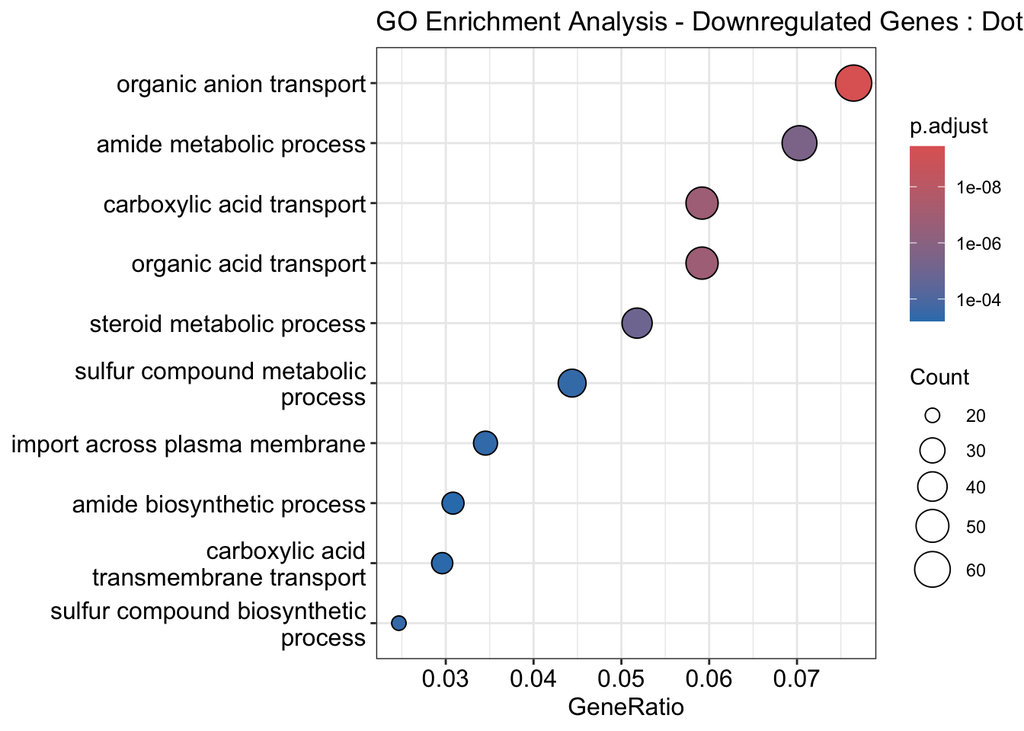

```r
dotplot(ego_result_dn, showCategory=10) +
  ggtitle("GO Enrichment Analysis - Downregulated Genes : Dotplot")
```

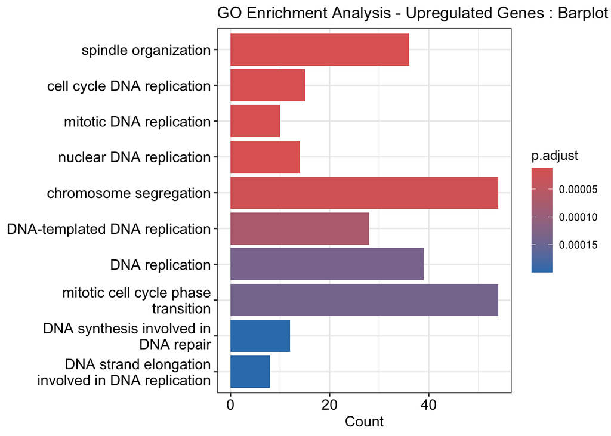

```r
barplot(ego_result_up, showCategory=10) +
  ggtitle("GO Enrichment Analysis - Upregulated Genes : Barplot")
```

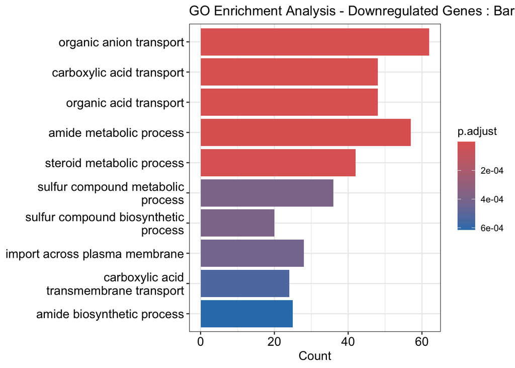

```r
barplot(ego_result_dn, showCategory=10) +
  ggtitle("GO Enrichment Analysis - Downregulated Genes : Barplot")
```

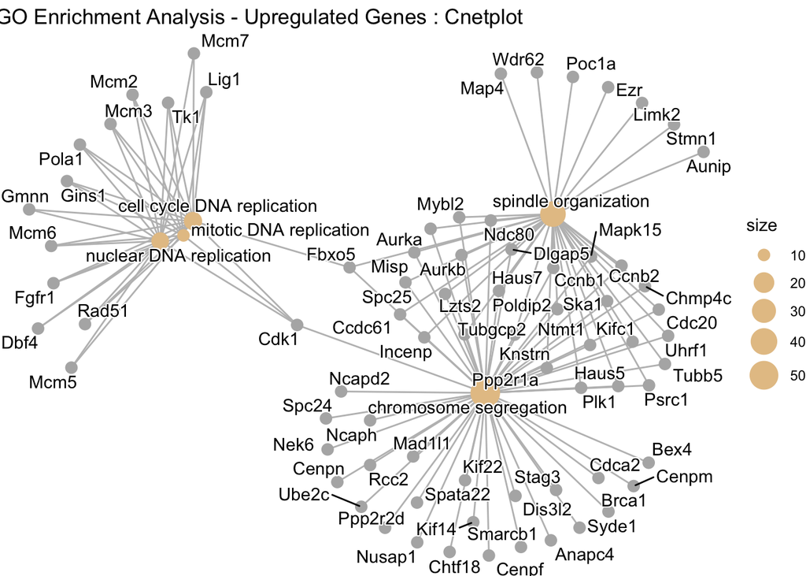

```r
#Category gene network plots
cnetplot(ego_result_up, categorySize="pvalue", foldChange=NULL) +
  ggtitle("GO Enrichment Analysis - Upregulated Genes : Cnetplot")
```

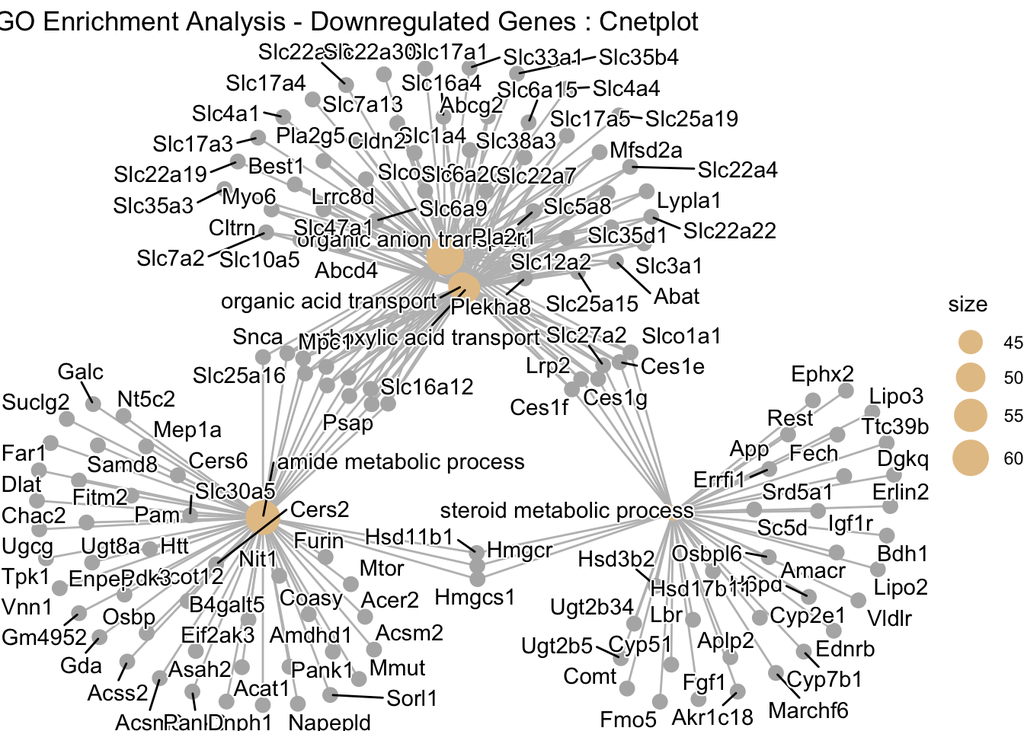

```r
cnetplot(ego_result_dn, categorySize="pvalue", foldChange=NULL) +
  ggtitle("GO Enrichment Analysis - Downregulated Genes : Cnetplot")
```

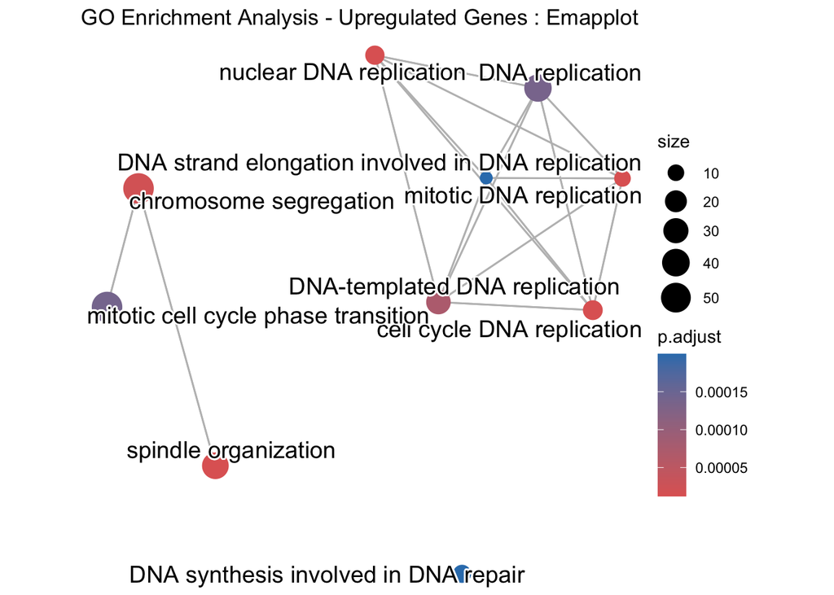

```r
#Emapplots
ego_result_up_enrich <- enrichplot::pairwise_termsim(ego_result_up)
ego_result_dn_enrich <- enrichplot::pairwise_termsim(ego_result_dn)
emapplot(ego_result_up_enrich, showCategory=10) +
  ggtitle("GO Enrichment Analysis - Upregulated Genes : Emapplot")
```

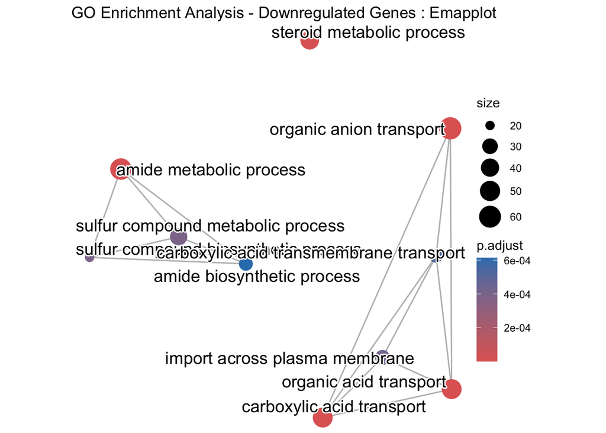

```r
emapplot(ego_result_dn_enrich, showCategory=10) +
  ggtitle("GO Enrichment Analysis - Downregulated Genes : Emapplot")
```

## Gene Set Enrichment Analysis

GSEA gene lists are ranked, by a principally arbitrary rank metric. The rank will be “walked down” and overlaps with the gene set will increase the score, while the score will decrease again for non-overlapping genes, giving a “curve”, thus also giving a “spacial” information, in which rank area the overlaps occur.

GSEA uses GO term descriptions and Normalized Enrichment Score (NES): A positive NES means → gene set is enriched at the top of the ranked list (upregulated). A negative NES means → gene set is enriched at the bottom (downregulated).

```r
##Create a ranked gene list for GSEA
#use the Wald statistic (res$stat):

df <- res_multi_df |>
  dplyr::filter(!is.na(padj)) |>
  dplyr::arrange(desc(stat)) |>
  dplyr::filter(!is.na(gene_symbol))

geneList <- df$stat
names(geneList) <- df$gene_symbol

#using the external script
gsea_results <- runGSEA(
  geneList = geneList,
  OrgDb = org.Mm.eg.db,
  keyType = "SYMBOL",   # or "ENSEMBL", depending on your data
  ontologies = c("BP","MF","CC")
)

#1. Check what’s in the list
names(gsea_results)
```

```
## [1] "BP" "MF" "CC"
```

```r
#2. Convert to a data frame
bp_df <- as.data.frame(gsea_results$BP)
mf_df <- as.data.frame(gsea_results$MF)
cc_df <- as.data.frame(gsea_results$CC)

#3. View top pathways
head(bp_df[order(bp_df$p.adjust), ])
```

```
##                    ID                    Description setSize enrichmentScore
## GO:0007059 GO:0007059         chromosome segregation     395       0.4350542
## GO:0051276 GO:0051276        chromosome organization     493       0.4011850
## GO:0007051 GO:0007051           spindle organization     201       0.5128641
## GO:0098813 GO:0098813 nuclear chromosome segregation     286       0.4542456
## GO:0000819 GO:0000819   sister chromatid segregation     221       0.4524549
## GO:0006260 GO:0006260                DNA replication     261       0.4359635
##                 NES       pvalue     p.adjust       qvalue rank
## GO:0007059 2.182557 2.289846e-15 1.369557e-11 1.223742e-11 3464
## GO:0051276 2.054669 1.274914e-14 3.812630e-11 3.406704e-11 3389
## GO:0007051 2.378661 3.120396e-14 6.221029e-11 5.558684e-11 2829
## GO:0098813 2.197435 2.969718e-13 4.440471e-10 3.967700e-10 3464
## GO:0000819 2.124528 1.363140e-10 1.358824e-07 1.214152e-07 2563
## GO:0006260 2.087051 1.357203e-10 1.358824e-07 1.214152e-07 3089
##                              leading_edge
## GO:0007059 tags=39%, list=20%, signal=33%
## GO:0051276 tags=37%, list=19%, signal=30%
## GO:0007051 tags=40%, list=16%, signal=34%
## GO:0098813 tags=42%, list=20%, signal=34%
## GO:0000819 tags=36%, list=14%, signal=31%
## GO:0006260 tags=34%, list=17%, signal=29%
##                                                                                                                                                                                                                                                                                                          …
## GO:0007059                                                                                                                                             Bex4/Rcc2/Nusap1/Haus5/Lzts2/Ntmt1/Ube2c/Tubgcp2/Haus7/Spc24…
## GO:0051276 Pou5f1/Rpa2/Parp1/Nusap1/H1f10/Cenpv/Ube2c/Spc24/Rad51/Uhrf1…
## GO:0007051                                                                                                                                                                                                                                                                                               …
## GO:0098813                                                                                                                                                                                                                                                                                               …
## GO:0000819                                                                                                                                                                                                                                                                                               …
## GO:0006260                                                                                                                                                                                                                                                                                               …
```

```r
#4. Extract only the significant pathways
sig_bp <- bp_df[bp_df$p.adjust <= 0.05, ]

#5. Access specific info
# The column with actual contributing genes is 'core_enrichment'
bp_df$core_enrichment[1]
```

```
## [1] "Bex4/Rcc2/Nusap1/Haus5/Lzts2/Ntmt1/Ube2c/Tubgcp2/Haus7/Spc24…"
```

```r
# Split into vector
genes <- strsplit(bp_df$core_enrichment[1], "/")[[1]]

sig_bp[, c("Description", "NES", "p.adjust")]
```

```
##                                                                                        Description
## GO:0007059                                                                  chromosome segregation
## GO:0051276                                                                 chromosome organization
## GO:0007051                                                                    spindle organization
## GO:0098813                                                          nuclear chromosome segregation
## GO:0000819                                                            sister chromatid segregation
## GO:0006260                                                                         DNA replication
## GO:0000070                                                    mitotic sister chromatid segregation
## GO:0007052                                                            mitotic spindle organization
## GO:0000280                                                                        nuclear division
## GO:0051225                                                                        spindle assembly
## GO:1902850                               microtubule cytoskeleton organization involved in mitosis
## GO:0051310                                                          metaphase chromosome alignment
## GO:0050000                                                                 chromosome localization
## GO:0140014                                                                mitotic nuclear division
## GO:0006261                                                           DNA-templated DNA replication
## GO:0048285                                                                       organelle fission
## GO:0015711                                                                 organic anion transport
## GO:1903046                                                              meiotic cell cycle process
## GO:0006310                                                                       DNA recombination
## GO:0045132                                                          meiotic chromosome segregation
## GO:0140241                                                                  translation at synapse
## GO:0140242                                                              translation at postsynapse
## GO:0033260                                                                 nuclear DNA replication
## GO:0044786                                                              cell cycle DNA replication
## GO:0140236                                                               translation at presynapse
## GO:1902969                                                                 mitotic DNA replication
## GO:0044772                                                     mitotic cell cycle phase transition
## GO:0006302                                                              double-strand break repair
## GO:0097237                                                    cellular response to toxic substance
## GO:0008608                                       attachment of spindle microtubules to kinetochore
## GO:0051321                                                                      meiotic cell cycle
## GO:0000725                                                                  recombinational repair
## GO:0051983                                                    regulation of chromosome segregation
## GO:1990748                                                                 cellular detoxification
## GO:0006270                                                              DNA replication initiation
## GO:0007080                                                  mitotic metaphase chromosome alignment
## GO:0000724                                 double-strand break repair via homologous recombination
## GO:0140013                                                                meiotic nuclear division
## GO:0033044                                                   regulation of chromosome organization
```

[output cut: 383 more lines]

```
## GO:0098659 -1.651929 4.657604e-02
## GO:0099587 -1.651929 4.657604e-02
## GO:0000018  1.647407 4.657604e-02
## GO:0045931  1.611488 4.657604e-02
## GO:0033559  1.610322 4.657604e-02
## GO:0006090 -1.608395 4.657604e-02
## GO:0000910  1.537114 4.657604e-02
## GO:0042026 -1.879025 4.701058e-02
## GO:0051987  1.850396 4.701058e-02
## GO:0061351  1.518367 4.701058e-02
## GO:0050790  1.472008 4.789411e-02
## GO:0008654 -1.515295 4.843623e-02
## GO:0015740 -1.894509 4.859359e-02
## GO:0043085  1.573392 4.923155e-02
## GO:0006575  1.552156 4.989940e-02
```

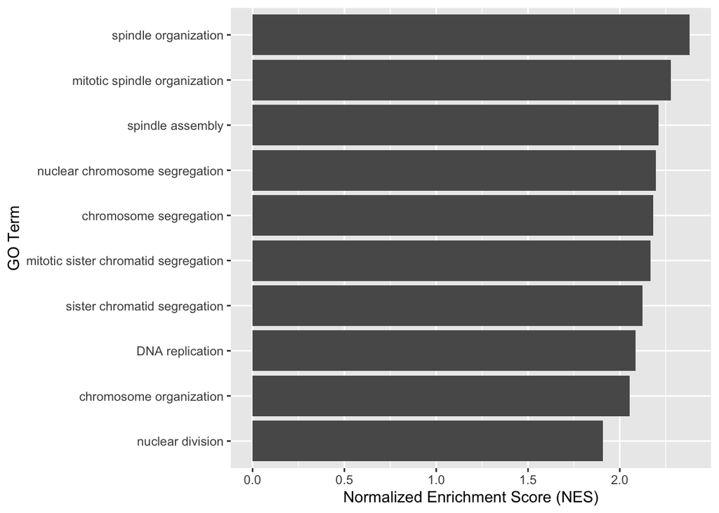

```r
#6 Plot results
bp_df <- as.data.frame(gsea_results$BP)
bp_df <- bp_df[order(bp_df$p.adjust), ][1:10, ]  # top 10

ggplot(bp_df, aes(x = reorder(Description, NES), y = NES)) +
  geom_bar(stat = "identity") +
  coord_flip() +
  labs(y = "Normalized Enrichment Score (NES)", x = "GO Term")
```

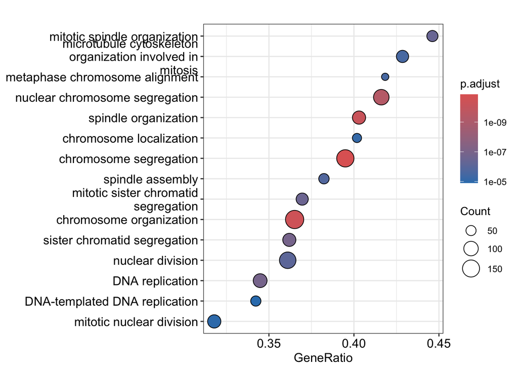

```r
# Dot plot
dotplot(gsea_results$BP, showCategory = 15)
```

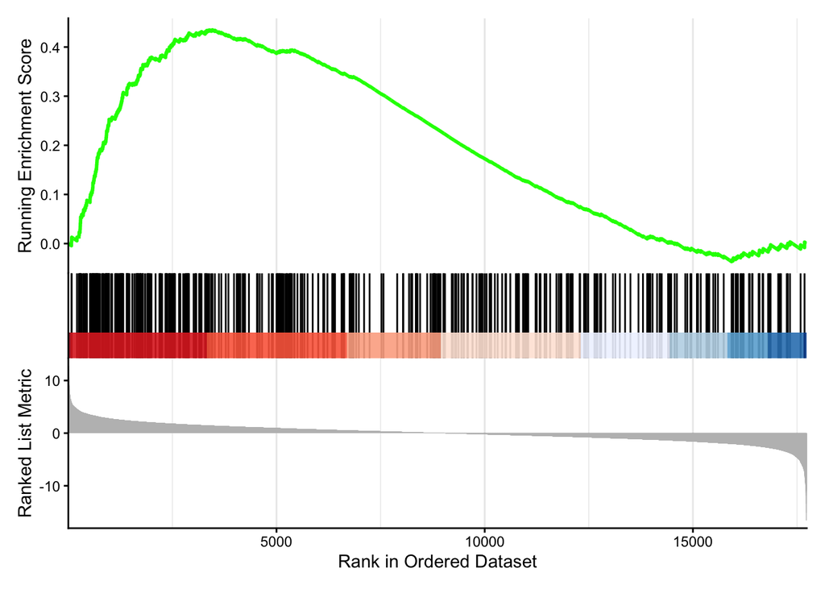

```r
# Enrichment plot for one gene set, at the moment for the most significant pathway (chromosome segregation)
gseaplot2(gsea_results$BP, geneSetID = sig_bp$ID[1])
```

## Volcano Plot of significant differentially expressed genes

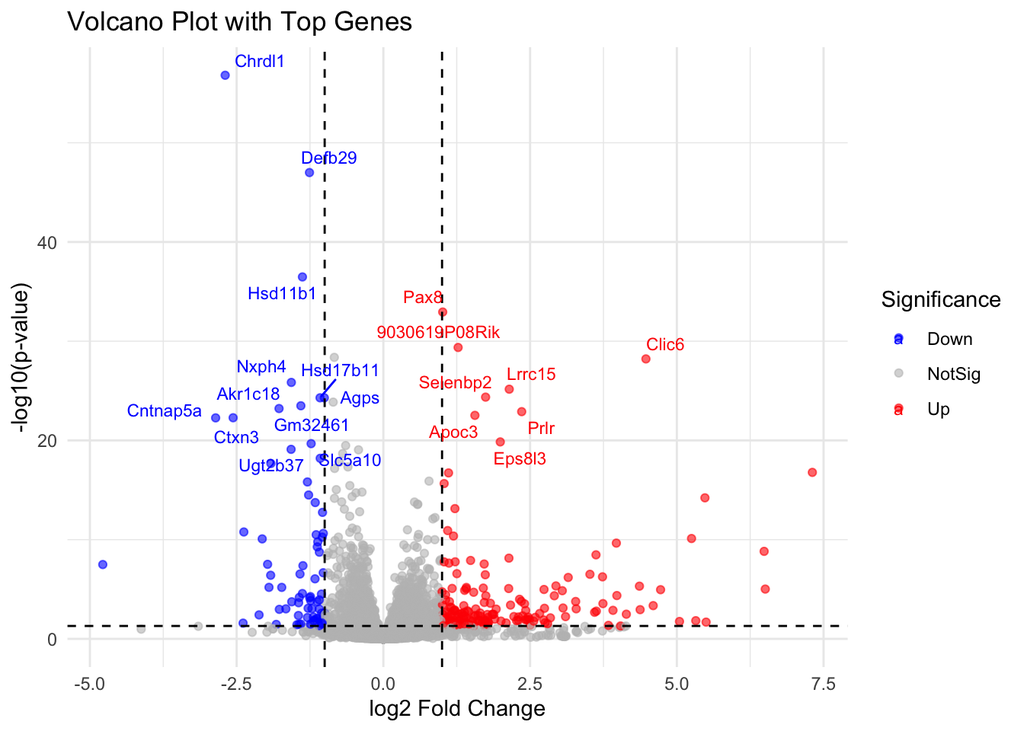

```r
#add significance and threshold
lfc_thresh <- 1       # log2 fold change threshold
p_thresh   <- 0.05    # adjusted p-value threshold

#add significance column
res_multi_df <- res_multi_df |>
  mutate(
    significant = ifelse(!is.na(padj) & padj <= p_thresh & abs(log2FoldChange) >= lfc_thresh,
                         ifelse(log2FoldChange > 0, "Up", "Down"),
                         "NotSig")
  )

# Select top 20 most significant genes
top_genes <- res_multi_df |>
  filter(significant != "NotSig") |>
  arrange(padj) |>
  slice_head(n = 20)  # pick 20 smallest padj

# Create a clean dataset for plotting, filter out NA of padj in genes (reduces number of genes by 5386)
res_plot <- res_multi_df |>
  filter(!is.na(padj) & !is.na(log2FoldChange) & padj > 0)

ggplot(res_plot, aes(x = log2FoldChange, y = -log10(padj), color = significant)) +
  geom_point(alpha = 0.6, size = 1.5) +
  scale_color_manual(values = c("Up" = "red", "Down" = "blue", "NotSig" = "grey")) +
  geom_vline(xintercept = c(-lfc_thresh, lfc_thresh), linetype = "dashed") +
  geom_hline(yintercept = -log10(p_thresh), linetype = "dashed") +
  geom_text_repel(data = top_genes, aes(label = gene_symbol), size = 3) +
  theme_minimal() +
  labs(x = "log2 Fold Change", y = "-log10(p-value)", color = "Significance") +
  ggtitle("Volcano Plot with Top Genes")
```